# Data Sources

Published

August 30, 2025

# 1. Port of Los Angeles – Monthly Container Statistics

**Data Source**: [Port of Los Angeles – Statistics](https://www.portoflosangeles.org/business/statistics/container-statistics)

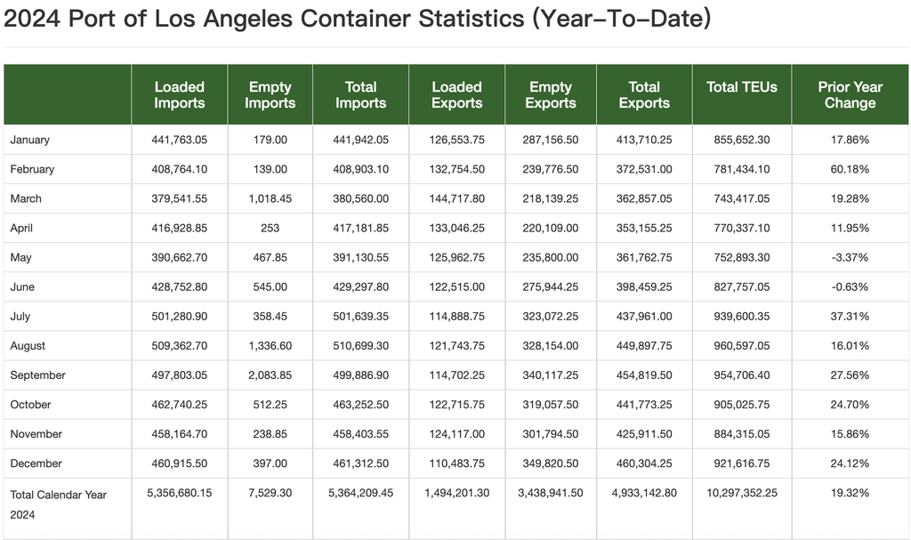

*2024 Port of LA Monthly TEUs*

**Description**:  
This dataset contains **monthly container throughput (TEU)** at the Port of Los Angeles from **January 1995 to December 2024**.  
The data includes detailed breakdowns:

- Loaded Imports
- Empty Imports
- Total Imports
- Loaded Exports
- Empty Exports
- Total Exports
- Total TEUs

# 2. Energy & Currency Factors

## 2.1 WTI Oil Price (WTISPLC)

**Data Source**: [FRED – Spot Crude Oil Price: West Texas Intermediate (WTI)](https://fred.stlouisfed.org/series/WTISPLC?utm_source=chatgpt.com)

[figure not shown]

*WTI Crude Oil Price (Monthly), Source: FRED*

**Description**:  
This dataset contains the **monthly spot price of West Texas Intermediate (WTI) crude oil**, expressed in U.S. dollars per barrel.  
The series covers **January 1946 to the present (latest data available: 2025)** and is maintained by the Federal Reserve Bank of St. Louis (FRED).

As a key indicator of **energy costs**, WTI oil prices strongly influence global shipping and logistics expenses.  
In this project, the WTI series will be used as an **external variable** to study how fluctuations in fuel costs impact the Port of Los Angeles container throughput (TEUs).

## 2.2 Brent Crude Oil Price (MCOILBRENTEU)

**Data Source**: [FRED – Crude Oil Prices: Brent – Europe (MCOILBRENTEU)](https://fred.stlouisfed.org/series/MCOILBRENTEU)

[figure not shown]

*Brent Crude Oil Price (Monthly), Source: FRED*

**Description**:  
This dataset contains the **monthly spot price of Brent crude oil**, expressed in U.S. dollars per barrel.  
The series covers **May 1987 to the present (latest data available: 2025)** and is maintained by the Federal Reserve Bank of St. Louis (FRED).

Brent crude serves as the **global benchmark for oil prices**, complementing WTI as the U.S. benchmark.  
In this project, the Brent series will be used to compare with WTI and analyze how **global energy price movements** influence container throughput at the Port of Los Angeles.

## 2.3 U.S. Dollar Index (DTWEXBGS)

**Data Source**: [FRED – Nominal Broad U.S. Dollar Index (DTWEXBGS)](https://fred.stlouisfed.org/series/DTWEXBGS)

[figure not shown]

**Description**:  
This dataset contains the **Nominal Broad U.S. Dollar Index**, a trade-weighted measure of the value of the U.S. dollar relative to a broad set of foreign currencies.  
The series covers **January 2006 to the present (latest data available: 2025)** and is maintained by the Federal Reserve Bank of St. Louis (FRED).

The U.S. Dollar Index is a critical financial indicator because it reflects **currency strength** and influences U.S. trade competitiveness.  
In this project, the index will be used as an **external driver** to study how exchange rate fluctuations affect the Port of Los Angeles container throughput (TEUs), especially in terms of imports and exports.

# 2.4 RMB/USD Exchange Rate (DEXCHUS)

**Data Source**: [FRED – China / U.S. Foreign Exchange Rate (DEXCHUS)](https://fred.stlouisfed.org/series/DEXCHUS)

[figure not shown]

*RMB/USD Exchange Rate (CNY per USD, Monthly Average), Source: FRED*

**Description**:  
This dataset contains the **China / U.S. foreign exchange rate (CNY per USD)**, provided by the Federal Reserve Bank of St. Louis (FRED).  
The series covers **January 1981 to the present (latest data available: 2025)**, with daily frequency that can be aggregated to monthly averages for analysis.

The RMB/USD exchange rate is a critical variable for studying **U.S.–China trade flows**.  
A depreciation of the RMB (more CNY per USD) makes Chinese exports cheaper, potentially increasing U.S. imports through the Port of Los Angeles.  
Conversely, an appreciation of the RMB makes Chinese exports more expensive, potentially reducing container throughput.  
In this project, the exchange rate will be used as an **external driver** to analyze its influence on the Port of Los Angeles TEU volumes.

# 3. Supply Chain & Policy Shocks

## 3.1 Global Supply Chain Pressure Index (GSCPI)

**Data Source**: [New York Fed – Global Supply Chain Pressure Index (GSCPI)](https://www.newyorkfed.org/research/policy/gscpi)  
**Download Link**: [GSCPI Monthly Data (Excel)](https://www.newyorkfed.org/medialibrary/research/interactives/gscpi/downloads/gscpi_data.xlsx)

[figure not shown]

*Global Supply Chain Pressure Index (Monthly), Source: NY Fed*

In this project, the GSCPI will be used as an **external variable** to analyze whether increased supply chain disruptions correspond with changes in container throughput at the Port of Los Angeles.

## 3.2 COVID-19 Stringency Index (U.S. & China)

**Data Source**: [Oxford COVID-19 Government Response Tracker (OxCGRT)](https://github.com/OxCGRT/covid-policy-dataset/blob/main/data/timeseries_indices/OxCGRT_timeseries_StringencyIndex_v1.csv)

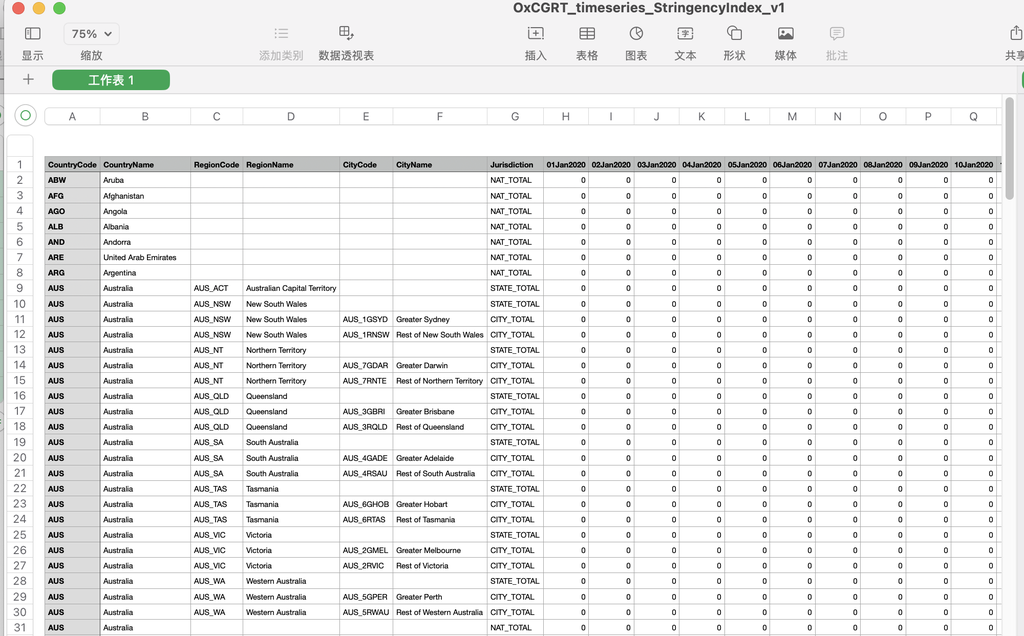

**Description**:  
This dataset provides the **COVID-19 Government Response Stringency Index** (0–100), compiled by the University of Oxford. The index measures the strictness of government containment policies, including school closures, travel restrictions, stay-at-home requirements, and public information campaigns.  
- **United States (USA)**: Represents demand-side disruptions, reflecting domestic policy restrictions that affected U.S. imports and consumption.  
- **China (CHN)**: Represents supply-side disruptions, reflecting export-side constraints caused by factory shutdowns, port closures, and mobility restrictions.

The data are available daily from **January 2020 to the present**. For this project, they are aggregated to **monthly averages** to align with the Port of Los Angeles container throughput (TEUs).

## 3.3 Tariff-Weighted Index (Advanced Tariff Shock Indicator)

**Data Source**: [AHS weighted average](https://wits.worldbank.org/CountryProfile/en/Country/WLD/StartYear/1988/EndYear/2022/TradeFlow/Import/Indicator/AHS-WGHTD-AVRG/Partner/WLD/Product/Total#)

[figure not shown]

AHS weighted average

**Description**:  
The AHS Weighted Average (%) indicator measures the average tariff rate applied to imported goods, weighted by their trade value. It provides a comprehensive picture of the effective protection level in global trade by combining both tariff rates and the composition of traded products. Unlike simple averages, this measure reflects the actual impact of tariffs on international trade flows and the degree of market openness over time.

# 4. Financial Market & Demand Indicators

## 4.1 S&P 500 Index (SP500)

**Data Source**: [FRED – S&P 500](https://fred.stlouisfed.org/series/SP500)

[figure not shown]

*Daily S&P 500 Index (aggregated to monthly for analysis). Source: FRED*

**Description**:  
This dataset provides the **S&P 500 Index**, a broad gauge of U.S. equity market performance and risk sentiment.  
Daily data will be **aggregated to monthly** to align with port TEU frequency.

## 4.2 Dow Jones Transportation Average (^DJT)

**Data Source**: [Yahoo Finance – ^DJT](https://finance.yahoo.com/quote/%5EDJT)

[figure not shown]

*Transportation stocks index (or IYT ETF) as a logistics/transport proxy. Source: Yahoo Finance*

**Description**:  
The **Dow Jones Transportation Average** (or **IYT ETF**) tracks transportation-related companies (airlines, rails, trucking).  
It captures investor expectations for logistics activity and freight demand.

## 4.3 U.S. Retail & Food Services Sales (RSAFS)

**Data Source**: [FRED – Retail and Food Services Sales (RSAFS)](https://fred.stlouisfed.org/series/RSAFS)

[figure not shown]

*Monthly U.S. Retail & Food Services Sales (seasonally adjusted). Source: FRED*